# Table of Contents

## Imports

## Get Data

```python
infp = Path(data_dir / "tiingo_etf_returns_ending_2017-12-31.parq")
R = pd.read_parquet(infp).assign(year=lambda df: df.index.year)
cprint(R)
```

```
-------------------------------------------------------------------------------
dataframe information
-------------------------------------------------------------------------------
                 SPY       QQQ       TLT       GLD       EFA       EEM  year
date
2017-12-22 -0.000262 -0.001143  0.001363  0.005223  0.002571  0.008422  2017
2017-12-26 -0.001197 -0.005416  0.002961  0.006839 -0.000285 -0.000861  2017
2017-12-27  0.000486  0.000128  0.012941  0.003770  0.001853  0.002580  2017
2017-12-28  0.002055  0.001213 -0.000868  0.005060  0.000569  0.006846  2017
2017-12-29 -0.003778 -0.006208  0.001578  0.006491  0.000711  0.004680  2017
--------------------------------------------------
<class 'pandas.core.frame.DataFrame'>
DatetimeIndex: 3301 entries, 2004-11-19 to 2017-12-29
Data columns (total 7 columns):
SPY     3301 non-null float64
QQQ     3301 non-null float64
TLT     3301 non-null float64
GLD     3301 non-null float64
EFA     3301 non-null float64
EEM     3301 non-null float64
year    3301 non-null int64
dtypes: float64(6), int64(1)
memory usage: 206.3 KB
None
-------------------------------------------------------------------------------
```

## Analysis Functions

```python
def to_returns(s):
    return np.log(s / s.shift(1)).dropna()


def to_price_index_exp(df, start=100):
    return start * (np.exp(df.cumsum()))


def to_price_index_sum(df, start=100):
    return start + df.cumsum()


def cdescribe(x, n_cols=None):
    if not n_cols:
        d = x.describe()
        d.loc["skew"] = x.skew()
        d.loc["kurtosis"] = x.kurtosis()
        return d
    else:
        x_ = x.sample(n_cols, axis=1)
        d = x_.describe()
        d.loc["skew"] = x_.skew()
        d.loc["kurtosis"] = x_.kurtosis()
        return d


def compare_stats(x, y, n_cols=None):
    pd.options.display.float_format = "{:,.4f}".format
    data = pd.concat([cdescribe(x), cdescribe(y, n_cols=n_cols)], axis=1)
    return data
```

## Plot Functions

```python
def plot_autocorr(s, lags=50, figsize=(12, 8), title=None):
    fig = plt.figure(figsize=figsize)
    layout = 2, 2
    acf_ax = plt.subplot2grid(layout, (0, 0))
    abs_acf_ax = plt.subplot2grid(layout, (0, 1))
    pacf_ax = plt.subplot2grid(layout, (1, 0))
    squared_ax = plt.subplot2grid(layout, (1, 1))

    sm.graphics.tsa.plot_acf(
        s,
        fft=True,
        zero=False,
        lags=lags,
        ax=acf_ax,
        title="Autocorrelation of Returns",
    )

    sm.graphics.tsa.plot_acf(
        s.abs(),
        fft=True,
        zero=False,
        lags=lags,
        ax=abs_acf_ax,
        title="Autocorrelation of Absolute Returns",
    )

    sm.graphics.tsa.plot_pacf(
        s, zero=False, lags=lags, ax=pacf_ax, title="Partial Autocorrelation of Returns"
    )

    sm.graphics.tsa.plot_acf(
        s ** 2,
        fft=True,
        zero=False,
        lags=lags,
        ax=squared_ax,
        title="Autocorrelation of Squared Returns",
    )

    if title:
        fig.suptitle(title, fontweight="demi", fontsize=16)
    fig.tight_layout()
    fig.subplots_adjust(top=0.88)
    return


def plot_mean_dist(returns, sim_returns, ax):

    mean_return = returns.mean()

    ax.set_title(f"{returns.name} mean return: {mean_return:.4f}")
    sim_means = sim_returns.mean().squeeze()

    g = sns.distplot(sim_means, kde=False, ax=ax)
    g.axvline(mean_return, color="r")
    return


def plot_std_dist(returns, sim_returns, ax):

    std = returns.std()

    ax.set_title(f"{returns.name} return std: {std:.4f}")
    sim_stds = sim_returns.std().squeeze()

    g = sns.distplot(sim_stds, kde=False, ax=ax)
    g.axvline(std, color="r")
    return


def plot_min_dist(returns, sim_returns, ax):

    min_ = returns.min()

    ax.set_title(f"{returns.name} return min: {min_:.4f}")
    sim_mins = sim_returns.min().squeeze()

    g = sns.distplot(sim_mins, kde=False, ax=ax)
    g.axvline(min_, color="r")
    return


def plot_max_dist(returns, sim_returns, ax):

    max_ = returns.max()

    ax.set_title(f"{returns.name} return max: {max_:.4f}")
    sim_maxs = sim_returns.max().squeeze()

    g = sns.distplot(sim_maxs, kde=False, ax=ax)
    g.axvline(max_, color="r")
    return


def plot_stat_dist(returns, sim_returns, figsize=(12, 8)):
    fig, axes = plt.subplots(2, 2, figsize=figsize)

    returns.name = "real_etf"
    plot_mean_dist(returns, sim_returns, axes[0, 0])
    plot_std_dist(returns, sim_returns, axes[0, 1])
    plot_min_dist(returns, sim_returns, axes[1, 0])
    plot_max_dist(returns, sim_returns, axes[1, 1])

    fig.suptitle(
        f"{returns.name} simulated stat distributions", fontweight="demi", fontsize=16
    )
    fig.tight_layout()
    fig.subplots_adjust(top=0.88)
    return


def plot_autocorr_dist(returns, sim_returns):

    autocorr = returns.autocorr()

    plt.title(f"{returns.name} return autocorr: {autocorr:.4f}")
    sim_autocorrs = sim_returns.apply(pd.Series.autocorr).squeeze()

    g = sns.distplot(sim_autocorrs, kde=False)
    g.axvline(autocorr, color="r")
    return
```

## Scale and Transform Data

```python
from sklearn.preprocessing import PowerTransformer, MaxAbsScaler, RobustScaler

R_pct = R.iloc[:, :-1].mul(100)
pt = RobustScaler(
    quantile_range=(2.5, 97.5)
)  # PowerTransformer(method="yeo-johnson", standardize=True)
data = pt.fit_transform(R_pct)
data.shape
```

```
(3301, 6)
```

## Begin Analysis

### Find AIC, BIC Minimum

```python
## careful this can take >6 mins
n_components = np.arange(250, 2750, 250)
models = [
    mix.GaussianMixture(n, covariance_type="full", random_state=0) for n in n_components
]
aics = pd.Series(
    [model.fit(data).aic(data) for model in models], index=n_components, name="aic"
)
bics = pd.Series(
    [model.fit(data).bic(data) for model in models], index=n_components, name="bic"
)
```

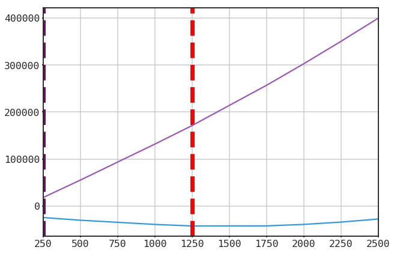

```python
fig, ax = plt.subplots()
_ = aics.plot(ax=ax)
ax.axvline(aics.idxmin(), color="red", ls="--", lw=7)

_ = bics.plot(ax=ax)
ax.axvline(bics.idxmin(), color="purple", ls="--", lw=7)
```

### Fit Mixture Model

```python
gmm = mix.GaussianMixture(aics.idxmin(), n_init=3, covariance_type="full")
gmm.fit(data)
print(gmm.converged_)
```

```
True
```

## Evaluate Single Path Sample

```python
def sample_path(gmm_model, transformer, n_samples, seed=0):
    np.random.seed(seed)
    data_new = gmm_model.sample(n_samples)[0]
    paths = transformer.inverse_transform(data_new)
    path_df = pd.DataFrame(paths)
    return path_df
```

```python
N_SAMPLES = len(data)
path_df = sample_path(gmm, pt, N_SAMPLES)
```

### Real data plot

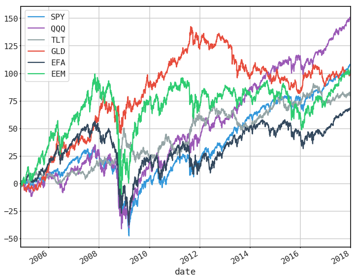

```python
_ = R_pct.cumsum().plot(figsize=(12, 10))
```

### Synthetic data plot

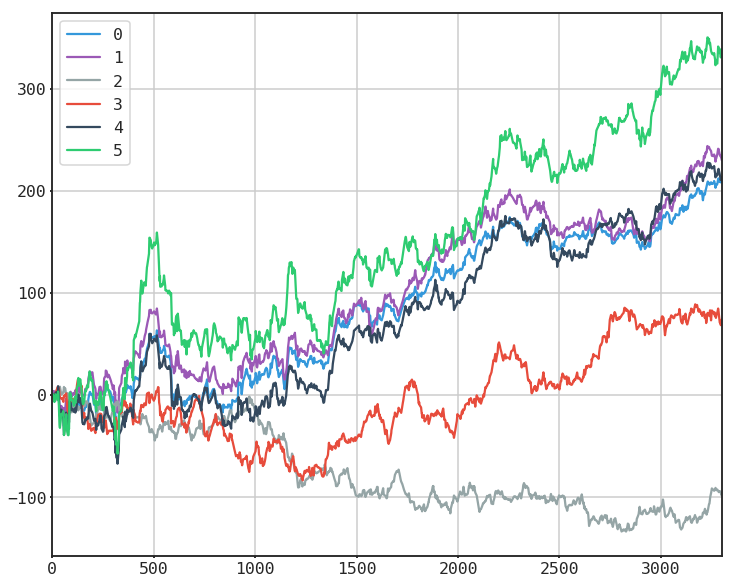

```python
_ = path_df.cumsum().plot(figsize=(12, 10))
```

### Compare histogram density

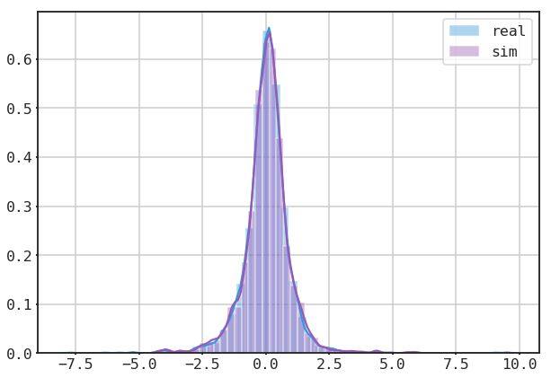

```python
fig, ax = plt.subplots()
sns.distplot(R_pct.mean(axis=1), ax=ax, label="real")
sns.distplot(path_df.mean(axis=1), ax=ax, label="sim")
ax.legend()
```

### Compare descriptive statistics

```python
compare_stats(R_pct, path_df).T
```

|  | count | mean | std | min | 25% | 50% | 75% | max | skew | kurtosis |
| --- | --- | --- | --- | --- | --- | --- | --- | --- | --- | --- |
| SPY | 3,301.0000 | 0.0326 | 1.1776 | -10.1640 | -0.3754 | 0.0660 | 0.5336 | 13.0685 | -0.1341 | 15.2330 |
| QQQ | 3,301.0000 | 0.0452 | 1.2572 | -9.3824 | -0.4830 | 0.0911 | 0.6567 | 11.4799 | -0.1257 | 7.8209 |
| TLT | 3,301.0000 | 0.0249 | 0.8761 | -5.1767 | -0.4901 | 0.0553 | 0.5365 | 5.0371 | -0.0190 | 1.8800 |
| GLD | 3,301.0000 | 0.0310 | 1.1991 | -9.1905 | -0.5424 | 0.0563 | 0.6686 | 10.6974 | -0.3076 | 5.9959 |
| EFA | 3,301.0000 | 0.0209 | 1.4326 | -11.8369 | -0.5321 | 0.0593 | 0.6787 | 14.7451 | -0.1557 | 12.5111 |
| EEM | 3,301.0000 | 0.0315 | 1.9389 | -17.6334 | -0.8442 | 0.0965 | 0.9404 | 20.5141 | 0.1936 | 14.7749 |
| 0 | 3,301.0000 | 0.0632 | 1.1487 | -7.0912 | -0.3447 | 0.0880 | 0.5611 | 13.0614 | 0.0988 | 11.4614 |
| 1 | 3,301.0000 | 0.0696 | 1.2312 | -6.2080 | -0.4673 | 0.0961 | 0.6987 | 11.4774 | 0.1418 | 5.0027 |
| 2 | 3,301.0000 | -0.0293 | 0.8759 | -5.1814 | -0.5180 | 0.0276 | 0.5067 | 3.6889 | -0.3858 | 1.9443 |
| 3 | 3,301.0000 | 0.0225 | 1.1860 | -7.7289 | -0.5354 | 0.0557 | 0.6449 | 7.1052 | -0.5995 | 4.9229 |
| 4 | 3,301.0000 | 0.0644 | 1.3921 | -7.7590 | -0.5188 | 0.0915 | 0.7217 | 14.7437 | 0.3185 | 9.1792 |
| 5 | 3,301.0000 | 0.1021 | 1.9080 | -10.1001 | -0.7857 | 0.1329 | 0.9893 | 20.5172 | 0.7456 | 10.9967 |

### Compare Correlations

#### Real

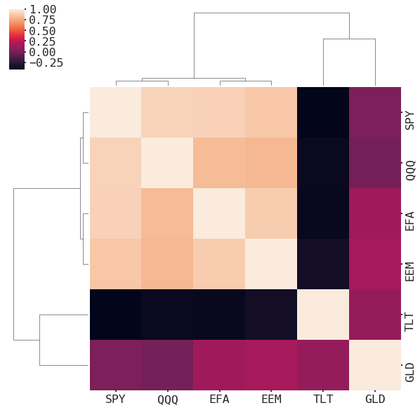

```python
sns.clustermap(R_pct.corr())
```

#### Synthetic

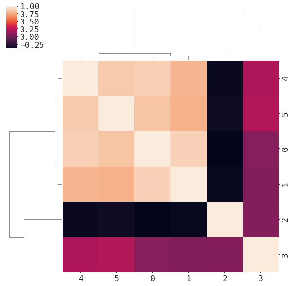

```python
sns.clustermap(path_df.corr())
```

### Plot example stat distributions

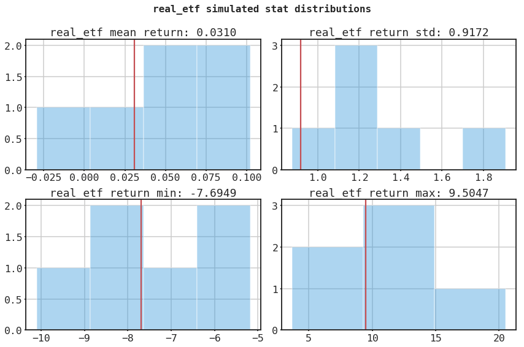

```python
plot_stat_dist(R_pct.mean(axis=1), path_df)
```

### Plot autocorrelations

#### Real

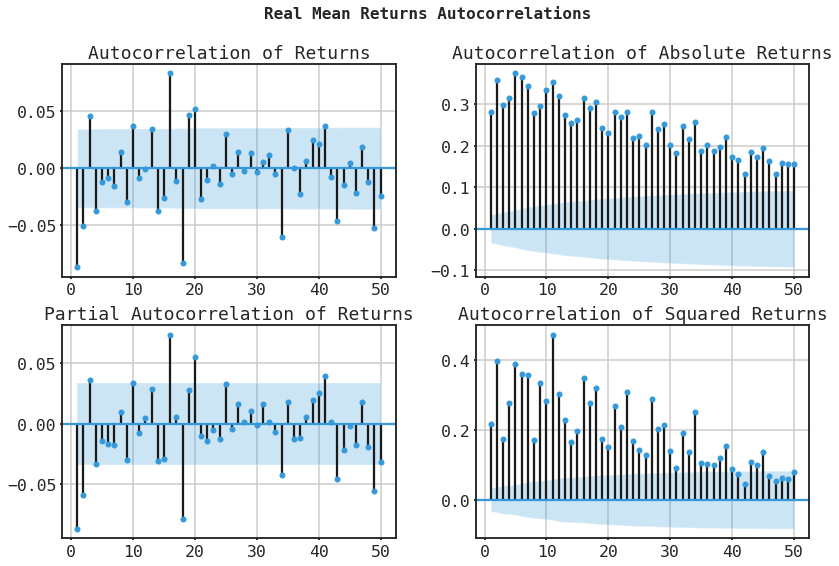

```python
plot_autocorr(R_pct.mean(axis=1), title="Real Mean Returns Autocorrelations")
```

#### Synthetic

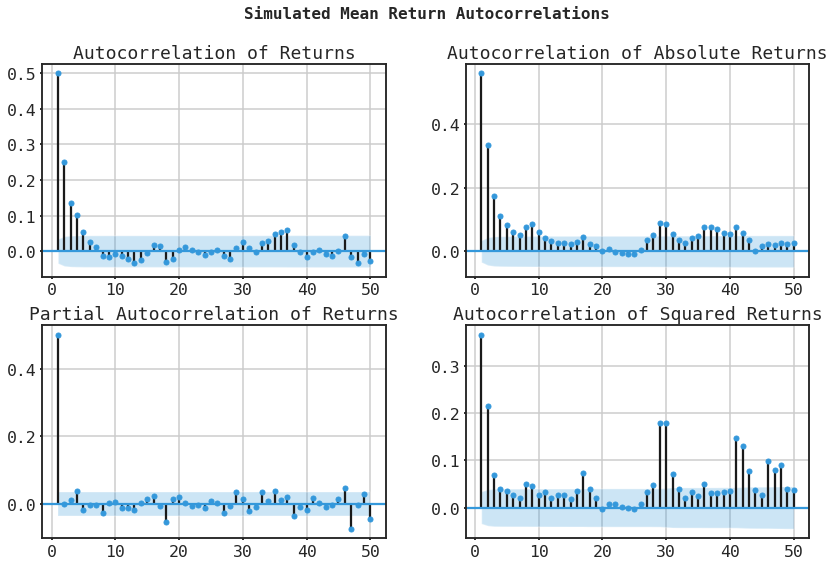

```python
plot_autocorr(path_df.mean(axis=1), title="Simulated Mean Return Autocorrelations")
```

## Evaluate Many Paths

```python
path_dfs = list()
for i in tqdm(range(int(5000 / 6))):
    path_df = sample_path(gmm, pt, N_SAMPLES, seed=i)
    path_dfs.append(path_df)

paths = pd.concat(path_dfs, axis=1)
paths.columns = np.arange(paths.shape[1])
cprint(paths)
```

```
-------------------------------------------------------------------------------
dataframe information
-------------------------------------------------------------------------------
        0       1       2      3       4       5       6       7       8       9     ...    4988    4989    4990    4991    4992    4993   4994   4995    4996    4997
3296  0.5962 -0.4723 -0.8383 1.0700  0.8320  2.7895 -0.9240 -1.0146 -0.2378 -1.6050  ...  0.5360 -1.9595 -1.5479 -1.6083 -0.7385 -0.9492 0.7755 1.0338 -0.0969 -0.5895
3297  0.5958 -0.4853 -0.8314 1.0739  0.8311  2.7969  0.5907 -0.4814 -0.8281  1.0734  ... -0.1942 -0.3932 -1.1604 -0.2333 -0.6888 -0.8453 0.8455 1.1289 -0.2279 -0.6704
3298  0.5957 -0.4846 -0.8351 1.0697  0.8198  2.7986 -0.9117 -0.7246  0.9425  0.6990  ... -0.2949 -0.0912 -1.0195 -0.2119 -0.6356 -0.8945 0.8239 1.2172 -0.1857 -0.8031
3299 -0.7101 -1.0065  0.6090 1.2230 -0.3330 -0.9851 -0.6784 -0.7974  0.8515  1.1884  ... -0.2356 -1.6057 -0.9591 -3.1173 -0.6599 -0.8734 0.7320 1.2673 -0.3875 -0.9484
3300 -0.6280 -0.9970  0.6703 1.2900 -0.2749 -1.0431 -0.8262 -0.7244  0.7384  1.0918  ... -0.2291 -1.6137 -0.9532 -3.1094 -0.9077 -0.7789 0.9012 0.7492 -0.1063 -0.0608

[5 rows x 4998 columns]
--------------------------------------------------
<class 'pandas.core.frame.DataFrame'>
RangeIndex: 3301 entries, 0 to 3300
Columns: 4998 entries, 0 to 4997
dtypes: float64(4998)
memory usage: 125.9 MB
None
-------------------------------------------------------------------------------
```

### Synthetic data plot

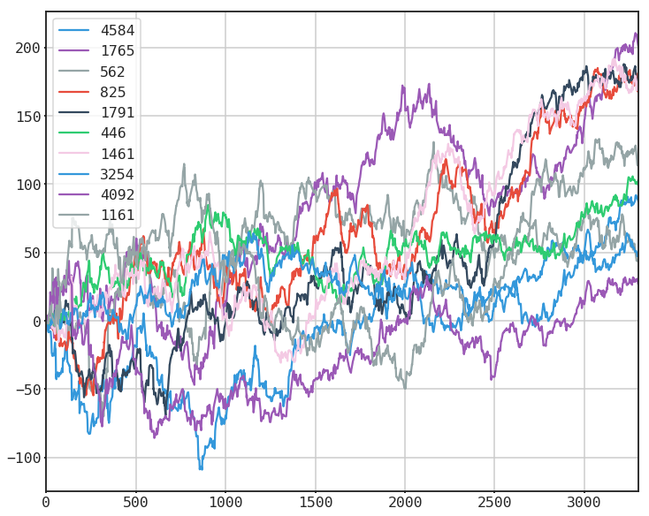

```python
paths.sample(10, axis=1, random_state=0).cumsum().plot(figsize=(12, 10))
```

### Plot Histogram Comparisons

#### Random selection of 6 Paths

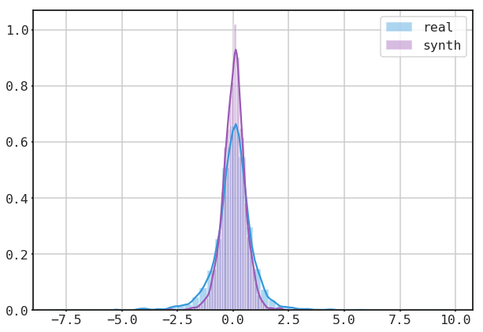

```python
fig, ax = plt.subplots()
sns.distplot(R_pct.mean(axis=1), ax=ax, label="real")
sns.distplot(paths.sample(6, axis=1, random_state=0).mean(axis=1), ax=ax, label="synth")
ax.legend()
```

#### All Paths

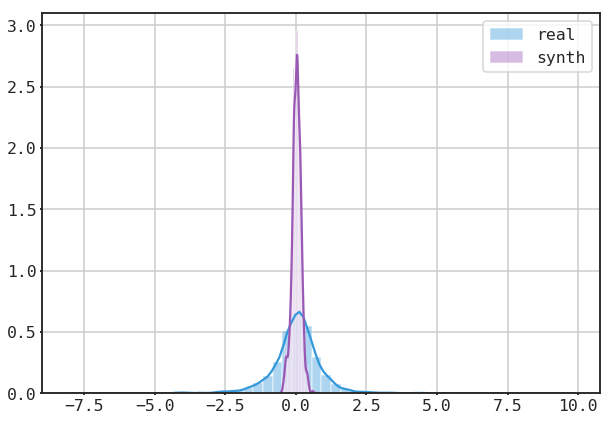

```python
fig, ax = plt.subplots()
sns.distplot(R_pct.mean(axis=1), ax=ax, label="real")
sns.distplot(paths.mean(axis=1), ax=ax, label="synth")
ax.legend()
```

### Compare descriptive statistics

```python
# change the number of columns to see more or use a subset of paths using paths.sample

compare_stats(R_pct, paths.iloc[:, :12], n_cols=10).T
```

|  | count | mean | std | min | 25% | 50% | 75% | max | skew | kurtosis |
| --- | --- | --- | --- | --- | --- | --- | --- | --- | --- | --- |
| SPY | 3,301.0000 | 0.0326 | 1.1776 | -10.1640 | -0.3754 | 0.0660 | 0.5336 | 13.0685 | -0.1341 | 15.2330 |
| QQQ | 3,301.0000 | 0.0452 | 1.2572 | -9.3824 | -0.4830 | 0.0911 | 0.6567 | 11.4799 | -0.1257 | 7.8209 |
| TLT | 3,301.0000 | 0.0249 | 0.8761 | -5.1767 | -0.4901 | 0.0553 | 0.5365 | 5.0371 | -0.0190 | 1.8800 |
| GLD | 3,301.0000 | 0.0310 | 1.1991 | -9.1905 | -0.5424 | 0.0563 | 0.6686 | 10.6974 | -0.3076 | 5.9959 |
| EFA | 3,301.0000 | 0.0209 | 1.4326 | -11.8369 | -0.5321 | 0.0593 | 0.6787 | 14.7451 | -0.1557 | 12.5111 |
| EEM | 3,301.0000 | 0.0315 | 1.9389 | -17.6334 | -0.8442 | 0.0965 | 0.9404 | 20.5141 | 0.1936 | 14.7749 |
| 0 | 3,301.0000 | 0.0632 | 1.1487 | -7.0912 | -0.3447 | 0.0880 | 0.5611 | 13.0614 | 0.0988 | 11.4614 |
| 4 | 3,301.0000 | 0.0644 | 1.3921 | -7.7590 | -0.5188 | 0.0915 | 0.7217 | 14.7437 | 0.3185 | 9.1792 |
| 6 | 3,301.0000 | 0.0270 | 1.1657 | -10.1632 | -0.3976 | 0.0576 | 0.5243 | 11.3837 | -0.5042 | 11.9878 |
| 3 | 3,301.0000 | 0.0225 | 1.1860 | -7.7289 | -0.5354 | 0.0557 | 0.6449 | 7.1052 | -0.5995 | 4.9229 |
| 7 | 3,301.0000 | 0.0431 | 1.2467 | -9.3837 | -0.4739 | 0.0885 | 0.6326 | 10.4765 | -0.3149 | 6.4675 |
| 10 | 3,301.0000 | 0.0138 | 1.4448 | -11.8406 | -0.5621 | 0.0576 | 0.6961 | 12.9054 | -0.6325 | 11.2251 |
| 11 | 3,301.0000 | 0.0233 | 1.9097 | -17.6366 | -0.8243 | 0.0957 | 0.9375 | 19.0091 | -0.5722 | 13.1705 |
| 8 | 3,301.0000 | 0.0148 | 0.8954 | -5.1726 | -0.5209 | 0.0492 | 0.5734 | 3.4987 | -0.1846 | 1.4280 |
| 5 | 3,301.0000 | 0.1021 | 1.9080 | -10.1001 | -0.7857 | 0.1329 | 0.9893 | 20.5172 | 0.7456 | 10.9967 |
| 1 | 3,301.0000 | 0.0696 | 1.2312 | -6.2080 | -0.4673 | 0.0961 | 0.6987 | 11.4774 | 0.1418 | 5.0027 |

### Compare Correlations

#### Real

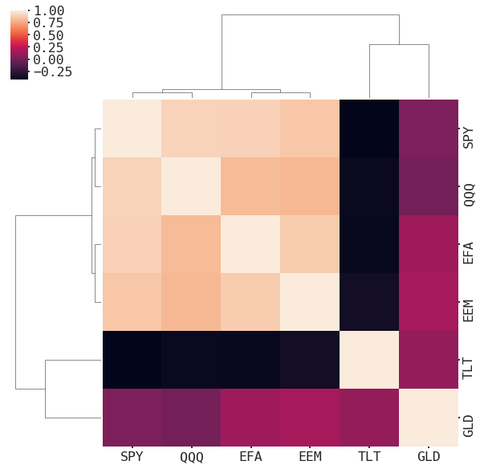

```python
sns.clustermap(R_pct.corr())
```

#### Synthetic first 12

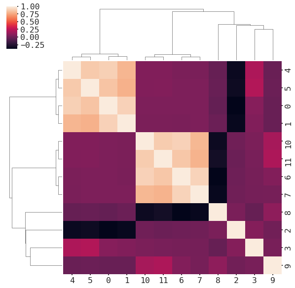

```python
sns.clustermap(paths.iloc[:, :12].corr())
```

### Plot example stat distributions

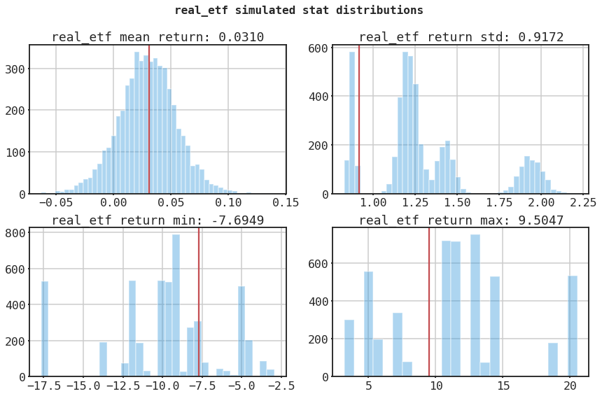

```python
plot_stat_dist(R_pct.mean(axis=1), paths)
```

### Plot Autocorrelations

#### Real

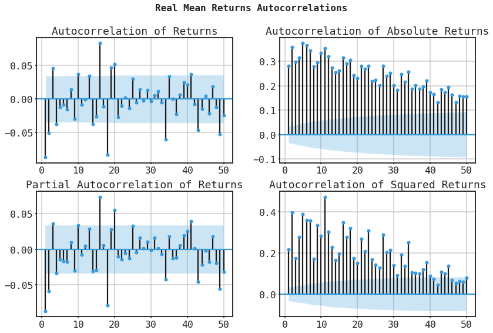

```python
plot_autocorr(R_pct.mean(axis=1), title="Real Mean Returns Autocorrelations")
```

#### Synthetic

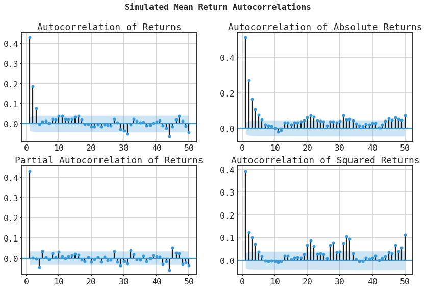

```python
plot_autocorr(path_df.mean(axis=1), title="Simulated Mean Return Autocorrelations")
```

## Conclusions

However there are some limitations. The simulated autocorrelations are too signficant and positive in the shorter lags, relative to the real data. Using a random sample of the simulated data can vastly alter the descriptive statistics, the correlations, and the histogram. This seems to be a result of the GMM being fit on a correlated group of data, so that the random samples may overuse a particular version of a return path, which when aggregated together could show extreme kurtosis or a shifted skew.

Another limitation is the computational burden this method requires. If the dataset gets larger than 20K rows the time and memory requirements become prohibitive and may jam your laptop/desktop computer.